# Ejercicio 4

Regresar a la página principal

## Análisis de contaminantes en rábanos

Si las legumbres destinadas al consumo humano contienen algún plaguicida, éste debe presentarse concentraciones ínfimas. La detección de plaguicidas en legumbres se logra mediante el uso de solventes con el fin de extraer dichas sustancias. Posteriormente de la obtención de los extractos, estos deben ser sometidos a la técnica de cromatografía liquida para aislar y cuantificar los compuestos presentes.

El Dieldrin (plaguicida de uso común) marcado como carbono 14 (radioactivo) se aplicó a rábanos en crecimiento y 14 días después se empleó el proceso de extracción y se analizaron los extractos en busca de algún residual presente.  
La siguiente tabla muestra los datos obtenidos del experimento al determinar el % de carbono14 presente en la pulpa del rábano empleando cantidades bajas, medias y altas de un solvente en el proceso de extracción:

| Porcentaje de carbono-14 en la pulpa de rábano |  |  |
| --- | --- | --- |
| Concentración del solvente |  |  |
| Baja | Media | Alta |
| 23.37 | 20.39 | 18.87 |
| 25.13 | 20.87 | 19.69 |
| 23.78 | 20.78 | 19.29 |
| 27.74 | 20.19 | 18.1 |
| 25.3 | 20.01 | 18.42 |
| 25.21 | 20.23 | 19.33 |
| 22.12 | 20.73 | 17.26 |
| 20.96 | 19.53 | 18.09 |
| 23.11 | 18.87 |  |
| 22.57 |  |  |

# Factores perturbadores del experimento

A continuación enuncio algunos de los factores que pueden afectar éste experimento en específico:

- Variabilidad en las condiciones de crecimiento de los rábanos: Diferencias en el suelo, la luz, la temperatura y otros factores ambientales durante el crecimiento de los rábanos podrían influir en la absorción y distribución del dieldrin marcado con carbono 14 en las plantas, lo que puede afectar significativamente los resultados.
- Contaminación: Puede haber fallas en el proceso de extracción o del análisis, lo que podría introducir errores en los resultados. Por ejemplo, la presencia de dieldrin marcado con carbono 14 en equipos de laboratorio o reactivos que pueden contaminar las muestras y generar resultados falsos.
- Variabilidad en los métodos de extracción: Pequeñas diferencias los métodos de extracción, como la duración o la agitación u otros, podrían afectar la eficiencia de la extracción del dieldrin marcado con carbono 14 de los rábanos, lo que influiría en los resultados.
- Error experimental: Errores aleatorios o sistemáticos en la medición de los porcentajes de carbono 14 podrían introducir sesgos en los datos y afectar la precisión de las conclusiones.
- Interferencias químicas: La presencia de otros compuestos químicos en los rábanos o en el solvente de extracción podría interferir con la detección del dieldrin, lo que podría distorsionar los resultados.
- Tamaño de la muestra: Un tamaño de muestra insuficiente podría limitar la capacidad del experimento para detectar diferencias significativas entre los tratamientos.
- Variabilidad propia de las plantas: Las plantas son organismos biológicos complejos y pueden mostrar una variabilidad natural en la absorción y distribución de compuestos químicos, lo que podría afectar la reproducibilidad de los resultados.
- Variedades de los rábanos: Las variedades pueden tener diferentes reacciones a los tratamientos químicos, lo que significa que habría que tomar rábanos que tengan condiciones muy similares para que no se tengan conclusiones erroneas.
- Medición de las cantinades a aplicar: Al tratar de utilizar siempre una medida, así sea muy exacta pues tiene variaciones. La precisión en los equipos de medición, ese puede ser un factor que afecte los resultados del experimento.

# Modelo estadístico

El modelo de análisis estadístico para este experimento puede ser planteado de la siguiente manera:

$$Y_{ij} = \mu +
\tau_i+\epsilon_{ij}$$

- Donde $Y_{ij}$ representa la observación de la variable de interés (en este caso, el porcentaje de carbono 14) para la unidad experimental $j$ en el tratamiento $i$.
- $\mu$ es el parámetro de interés que representa la media global de la variable de interés.
- $\tau_i$ es el efecto del tratamiento $i$ (baja, media o alta concentración de solvente) sobre la variable de interés. Estos son los efectos fijos que queremos estimar.
- $\epsilon_{ij}$ es el error aleatorio asociado con la observación $Y_{ij}$ que incluye todas las fuentes de variabilidad no explicadas por los efectos del tratamiento.

Este modelo nos permite evaluar si hay diferencias significativas en el porcentaje de carbono 14 entre los diferentes tratamientos, controlando los efectos de otras fuentes de variabilidad. La prueba de hipótesis asociada con este modelo implica evaluar si los efectos de los tratamientos $\tau_i$ son significativamente diferentes de cero.

## Importando datos

Una vez creamos un archivo CSV, lo importamos. En éste caso se importara el archivo rabanos.csv.

```r
library(tidyverse)
rabanos <- read.csv("rabanos.csv")
rabanos
```

```
##     Baja Media  Alta
## 1  23.37 20.39 18.87
## 2  25.13 20.87 19.69
## 3  23.78 20.78 19.29
## 4  27.74 20.19 18.10
## 5  25.30 20.01 18.42
## 6  25.21 20.23 19.33
## 7  22.12 20.73 17.26
## 8  20.96 19.53 18.09
## 9  23.11 18.87    NA
## 10 22.57    NA    NA
```

## Pivot longer para reorganizar la tabla

A continuación se utiliza pivot_longer para poder pasar de una tabla de formato ancho a una tabla de formato largo

```r
rabanos <- rabanos %>% pivot_longer(cols = Baja:Alta, names_to = "Concentration",
                                  values_to = "C_14")
rabanos
```

```
## # A tibble: 30 × 2
##    Concentration  C_14
##    <chr>         <dbl>
##  1 Baja           23.4
##  2 Media          20.4
##  3 Alta           18.9
##  4 Baja           25.1
##  5 Media          20.9
##  6 Alta           19.7
##  7 Baja           23.8
##  8 Media          20.8
##  9 Alta           19.3
## 10 Baja           27.7
## # ℹ 20 more rows
```

# Analisis exploratorio de los datos

La unidad experimental es el rábano que ha sido tratado con dieldrin marcado con carbono 14 y sometido al proceso de extracción para determinar el porcentaje de carbono 14 presente en su pulpa. Cada rábano representa una observación individual y constituye la unidad básica sobre la cual se realizan las mediciones y análisis en el experimento. La variación en las concentraciones de solvente y los niveles de carbono 14 detectados se evalúa en relación con estas unidades experimentales, es decir, los rábanos individuales.

```r
#rabanos$Concentration <- as.factor(rabanos$Concentration)
rabanos$CARBONO <- as.factor(rabanos$C_14)

# Resumen
str(rabanos)
```

```
## tibble [30 × 3] (S3: tbl_df/tbl/data.frame)
##  $ Concentration: chr [1:30] "Baja" "Media" "Alta" "Baja" ...
##  $ C_14         : num [1:30] 23.4 20.4 18.9 25.1 20.9 ...
##  $ CARBONO      : Factor w/ 26 levels "17.26","18.09",..: 21 13 5 23 16 9 22 15 6 26 ...
```

```r
summary(rabanos)
```

```
##  Concentration           C_14          CARBONO
##  Length:30          Min.   :17.26   18.87  : 2
##  Class :character   1st Qu.:19.31   17.26  : 1
##  Mode  :character   Median :20.39   18.09  : 1
##                     Mean   :21.11   18.1   : 1
##                     3rd Qu.:22.84   18.42  : 1
##                     Max.   :27.74   (Other):21
##                     NA's   :3       NA's   : 3
```

# Análisis gráfico

En el experimento, los tratamientos son las diferentes concentraciones de solvente utilizadas en el proceso de extracción de dieldrin marcado con carbono 14 de los rábanos. Estas concentraciones de solvente son las variables independientes que se manipulan para investigar su efecto en el porcentaje de carbono 14 presente en la pulpa de los rábanos. Por lo tanto, los tratamientos en este experimento son las concentraciones baja, media y alta de solvente. Cada tratamiento representa una condición experimental única que se aplica a los rábanos en crecimiento y se evalúa para determinar su efecto en la cantidad de dieldrin marcado con carbono 14 extraído de los rábanos.

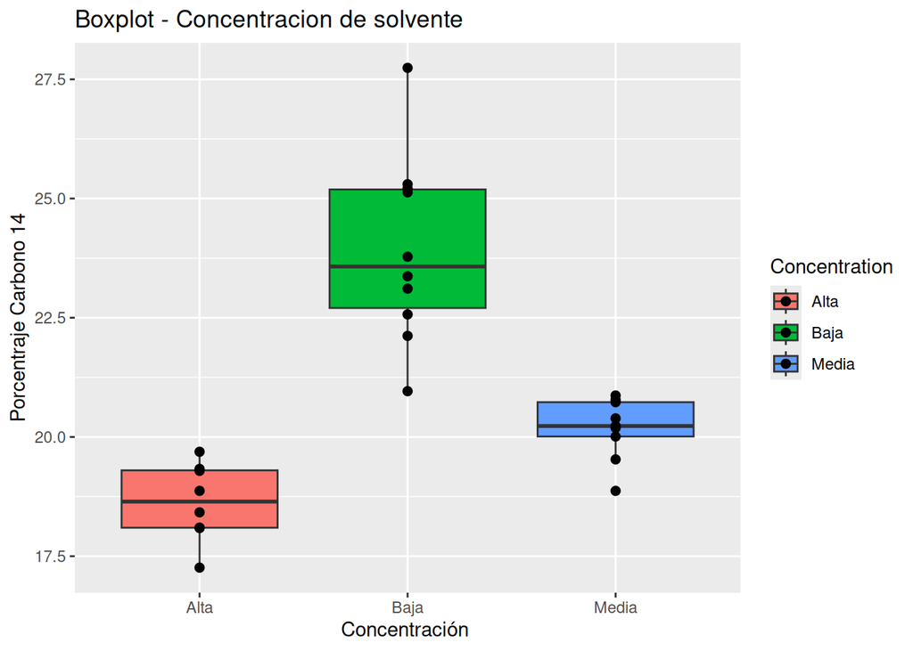

```r
bxp_concentration <- rabanos %>% ggplot(aes(x =Concentration , y = C_14, fill = Concentration)) + geom_boxplot() +
   geom_point(position = position_dodge(width = 0.75), size = 2) +
  labs(x = "Concentración ", y  = "Porcentraje Carbono 14", title = "Boxplot - Concentracion de solvente")

ggsave(plot = bxp_concentration, "bxp_temp.png", dpi = 300, units = "in", height = 6, width = 8)
bxp_concentration
```

Observamos que el rango de valores de carbono 14 va desde 17.26 hasta 27.74. La media es de aproximadamente 21.11, y la mediana es 20.39, lo que indica que la distribución puede estar sesgada hacia la derecha debido a que la media es mayor que la mediana.

Se puede ver que hay valores atípicos, que pueden representar condiciones excepcionales o anomalías en la relación entre la concentración del solvente y el porcentaje de carbono 14 en las legumbres.

Se puede observar que un mayor porcentaje de carbono 14 en los rábanos cuando se utiliza una baja concentración de solvente sugiere que la concentración del solvente en el proceso de extracción puede estar influyendo significativamente en los resultados del análisis de residuos de plaguicidas.